# Analyzing Text in Python

Joshua G. Mausolf

November 8, 2016

# Prerequisites:

If you have not already done so, you will need to properly install an Anaconda distribution of Python, following the installation [instructions from the first week](https://uc-cfss.github.io/setup00.html).

I would also recommend installing a friendly text editor for editing scripts such as [Atom](https://atom.io). Once installed, you can start a new script by simply typing in bash `atom name_of_your_new_script`. You can edit an existing script by using `atom name_of_script`. [SublimeText](https://www.sublimetext.com) also works similar to Atom. Alternatively, you may use a native text editor such as [Vim](https://www.linux.com/learn/vim-101-beginners-guide-vim), but this has a higher learning curve.

[*Note: If `atom` does not automatically work, try these solutions*](http://stackoverflow.com/questions/22390709/open-atom-editor-from-command-line).

### Installing New Python Packages

If you do not have a package, you may use the [Python package manager `pip`](https://packaging.python.org/installing/) (a default python program) to install it. Note that pip is called directly from the Shell (not in a python interpreter).

To begin, **update pip**.

#### On Mac or Linux

```bash
pip install -U pip setuptools
```

#### On Windows

```bash
python -m pip install -U pip setuptools
```

One program that may need to be installed is NLTK. Run `pip install nltk` in the Shell if needed.

To see further prerequisites, please visit the [tutorial README](https://github.com/jmausolf/Python_Tutorials/blob/master/Text_Keyword_Counter).

# Analyzing Text in Python

There are many ways to analyze text in Python. One popular package is [NLTK](http://www.nltk.org). We can actually perform simple analysis of text without NLTK. This module does just that. In particular, we can search a set of text files for one or more keywords and phrases, count the occurrence of those terms, and save the results as a CSV. That data can be visualized using standard methods to produce graphs such as the one below:

### [Discussion of Guns by President Obama and Congress, 2009-2016](https://public.tableau.com/views/DiscussionofGunsbyPresidentObamaandCongress2009-2016/Story1?:embed=y&:display_count=yes)

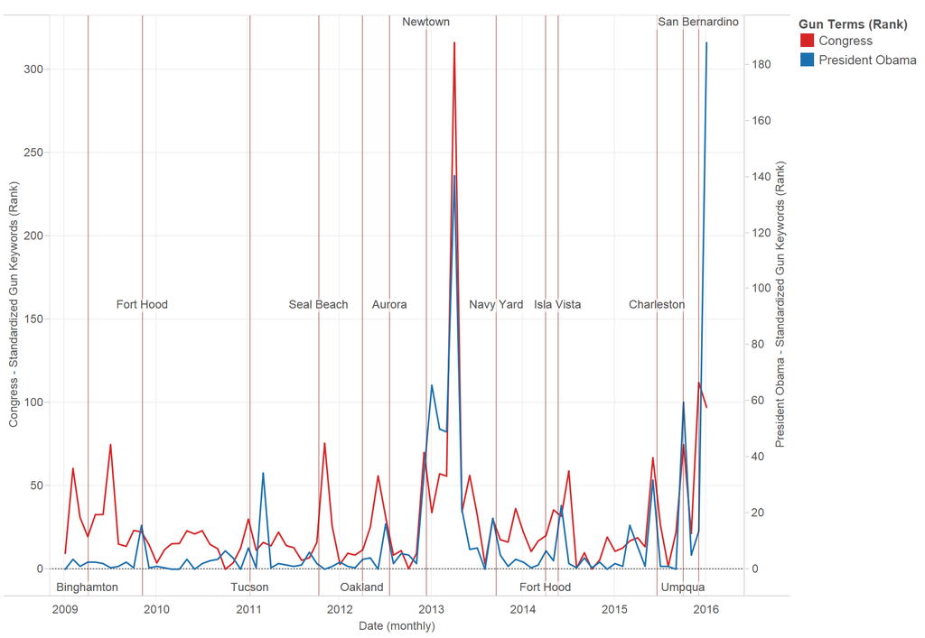

### Looking Under the Hood

##### [The full `text_keyword_classifier.py` script is available on Github.](https://github.com/jmausolf/Python_Tutorials/blob/master/Text_Keyword_Counter/text_keyword_classifier.py)

One of the main ways the code runs is by searching for ngrams, or particular phrases like `pay the fair share`, in this an ngram of length 4. In Python, we can count ngrams with a series of functions:

```python
def group_text(text, group_size):
    """
    This function groups a text into text groups.
    It returns a list of grouped strings.
    """
    word_list = text.split()
    group_list = []
    for k in range(len(word_list)):
        start = k
        end = k + group_size
        group_slice = word_list[start: end]

        # Append only groups of proper length/size
        if len(group_slice) == group_size:
            group_list.append(" ".join(group_slice))
    return group_list


def get_group_set(group_size, text):
    group_list = group_text(text, group_size)
    group_set = set(group_list)
    return group_set


def ngram(n, data):
    ngram = get_group_set(n, data)
    return ngram


def speech_phrase_counter(ngram1, ngram2, ngram3, ngram4, terms, df, n, sent):

    for term in terms:
        for gram in ngram4:
            if term == gram:
                count = sent.count(gram)
                df.ix[n, term] = count
        for gram in ngram3:
            if term == gram:
                count = sent.count(gram)
                df.ix[n, term] = count
        for gram in ngram2:
            if term == gram:
                count = sent.count(gram)
                df.ix[n, term] = count
        for gram in ngram1:
            if term == gram:
                count = sent.count(gram)
                df.ix[n, term] = count
```

These functions come together in the `speech_classifier` function, which loops over numerous speech files and writes the results to a CSV. While this function is complex, the key implementation of the above utility functions comes together in the following step:

```python
for speech in speech_files:

    #(Parts of Script Omitted for Clarity)

        sent = read_speech(speech)

        #Add Keyword Data
        ngram1 = get_group_set(1, sent)
        ngram2 = get_group_set(2, sent)
        ngram3 = get_group_set(3, sent)
        ngram4 = get_group_set(4, sent)

        #Count Keywords
        speech_phrase_counter(ngram1, ngram2, ngram3, ngram4, terms, df, n, sent)
```

# Running the Example

1. Git clone this repository: [`git clone https://github.com/jmausolf/Python_Tutorials/`](https://github.com/jmausolf/Python_Tutorials/)
2. Navigate to the Python Scripts folder in this repository and run the example:

   ```bash
   cd Python_Tutorials/Text_Keyword_Counter
   python find_keywords.py
   ```

# Modifying the Keywords for Your Purposes:

##### [The full `find_keywords.py` script is available on Github.](https://github.com/jmausolf/Python_Tutorials/blob/master/Text_Keyword_Counter/find_keywords.py)

To run the code, there are two steps:

##### 1. Define Your Keywords

##### 2. Run the Program

Below are some examples:

### 1. DEFINING YOUR KEYWORDS

##### Example 1: Keyword Categories with Keywords/Phrases

You can make one or more keyword lists to search:

```python
word_list_one = ["United States", "Canada"]
word_list_two = ["economy", "war"]
combined_terms = word_list_one+word_list_two
```

##### Example 2: Discussion of Guns and Shootings

```python
guns = ["_start", "firearm", "guns", "gun", "automatic weapons", "automatic weapon", "cheap handguns", "handguns", "shotgun", "shotguns", "rifle", "rifles", "Saturday night special", "high capacity magazines", "assualt rifles", "sawed off shotguns", "silencers", "AK-47s", "AR15", "AR-15s", "Glock", "Glocks"]
gun_laws = ["Second Amendment", "right to bear arms", "gunshow loophole", "gunshow", "gun dealer", "gun ownership", "gun sales", "gun manufacturers", "background check", "concealed carry", "ATF", "National Rifle Association", "NRA"]
gun_violence = ["mass shooting", "shootings", "guns don't kill people", "gun violence", "gunned down"]
shootings = ["Newtown", "San Bernardino", "Blacksburg", "Navy Yard", "Aurora", "Tucson", "Virginia Tech", "Fort Hood", "Charleston", "_end"]

gun_terms = guns+gun_laws+gun_violence+shootings
```

### 2. RUN THE PROGRAM

```python
from text_keyword_classifier import *

#Example Searching for Keywords in Presidential Data
speech_classifier("data/president", 0, 10, "White_House_data.csv", gun_terms, 1)
```

```bash
# In the Shell:
python find_keywords.py
```

##### What are these function inputs?

In short, the first parameter `"data/president"` defines where your data is located. `0, 10` describes the file name slice to implement. Here, the files have dates embedded such as “2011-09-17_ID1.txt”. `0, 10` correctly extracts the date from the file name. `"White_House_data.csv"` is the filename to save your results. `gun_terms` are defined above. These are your keywords. `1` selects the option to calculate NLTK metrics for the total number of words and tokens in a given speech file.

##### Full Function Documentation:

```python
"""
---------------------------------------------------------------------
    INSTRUCTIONS TO RUN THE PROGRAM
---------------------------------------------------------------------

    -   (1) To run the function, first define your full keyword list.
        Several examples are above.

---------------------------------------------------------------------

    -   (2) Next, select the folder with the speech files.
---------------------------------------------------------------------
    -   (3) Outline the string slice that contains the date for your
        text file.

        Your text file should contain a date of the file
        for example, 2011-09-17_ID1.txt or CREC-2015-01-03.txt.

    -   ds1:ds2     = - date slices of filenames
                    E.g. the filename "2011-09-17_ID1.txt"
                        would want date slices of
                        ds1 = 0 and ds2 = 10
                        This takes the string slice 0:10
                        and provides a date = 2011-09-17

---------------------------------------------------------------------
    -   (4) Specify the name of the output file.
---------------------------------------------------------------------
    -   (5) Specify other options if desired.
            See further documentation under speech_classifier
            documentation.

    speech_classifier(folder_name, ds1, ds2, output_file, terms,
                    metric=0, addtime=0, addloc=0, addcite=0):

---------------------------------------------------------------------
"""
```

#### Now that we have covered the basics, [FORK](https://github.com/jmausolf/Python_Tutorials/blob/master/README.md#fork-destination-box) this repository, modify the keywords, and analyze your own data.